# Een blik op de recensies van hotels in Amsterdam

| **Name** | **Student ID** | **Email** |
| --- | --- | --- |
| Nadine Allewijn | 11027541 | nadineallewijn@kpnplanet.nl |
| Thomas Dijkman | 11026057 | thomasdijkman@upcmail.nl |
| Andrea Pineda | 10590501 | mandreapinedac@gmail.com |
| Gavin Schipper | 11027592 | gavin_schipper@hotmail.com |

[figure not shown]

## ABSTRACT

In dit onderzoek is er gekeken naar wat wat voor conclusies er kunnen worden getrokken uit Booking.com reviews van hotels in Amsterdam. Er is allereerst gekeken naar het verband tussen de lengte van een review en het cijfer dat wordt gegeven. De correlatie hiertussen is echter maar 0.2. Vervolgens is gekeken of het sentiment van reviews kan worden voorspeld aan de hand van de gebruikte woorden. In tweederde van de gevallen is de gok juist. Tenslotte is er onderzocht of er een verschil bestaat tussen de review cijfers tussen de Amsterdamse stadsdelen. Dat is lastig, maar de spreidingen verschillen wel degelijk. Uit het onderzoek blijkt dus dat er verschillende conclusies kunnen worden aangenomen dankzij de reviews van hotels in Amsterdam.

## INTRODUCTIE

Vrijwel iedereen boekt tegenwoordig hotels online via de vele websites die hiervoor beschikbaar zijn. Op deze websites is het makkelijk om reviews achter te laten en ook te lezen hoe anderen mensen hun verblijf bij een bepaald hotel hebben ervaren. De websites leggen veel nadruk op de reviews omdat deze persoonlijk zijn en geen invloed bevatten van het hotel in kwestie. De reviews zeggen echter misschien nog veel meer dan een cijfer of een plus. Uit onderzoek van [Ye et al. (2009)](https://www.sciencedirect.com/science/article/pii/S0278431908000546) blijkt namelijk dat er een significante relatie is tussen online reviews en het aantal boekingen van een hotel. Reviews hebben daarom ook waarde voor de hotels, die steeds vaker aandacht besteden aan de reviews om zo een negatieve online indruk te voorkomen. Dit thema rond de beoordeling van hotels is wat wij wilden onderzoeken. Onze onderzoeksvraag luidt daarom: **"Wat voor conclusies kunnen uit reviews van hotels in Amsterdam worden getrokken?"**.

Om deze vraag te beantwoorden gebruiken wij data afkomstig van Booking.com, beschikbaar gesteld op [Kaggle.com](https://www.kaggle.com/jiashenliu/515k-hotel-reviews-data-in-europe). De dataset bevat 515 duizend reviews van bijna 1500 hotels in Europa in het luxere segment. Om het project specifieker en werkbaarder te maken, hebben wij gekozen om uit deze data alleen de hotels in Amsterdam te onderzoeken, met de overtuiging dat we hier ook betere conclusies en associaties over kunnen trekken aangezien het bekend terrein is. De deelvragen van dit onderzoek zijn:

- Is er een verband tussen de lengte van een review en het cijfer dat wordt gegeven?
- Kunnen we het sentiment van een reviews voorspellen aan de hand van de gebruikte woorden? Oftewel; positiviteit of negativiteit.
- Zijn er verschillen in cijfers tussen de Amsterdamse stadsdelen?

Dit onderzoek draagt bij aan de groeiende interesse in het gebuik van *user generated data* om inzicht te krijgen in problemen in de hotelwereld ([Ye et al., 2009](https://www.sciencedirect.com/science/article/pii/S0278431908000546)) en nieuwe perspectieven te bieden ([Xiang et al., 2015](https://www.sciencedirect.com/science/article/pii/S0278431914001698)). Het doel van dit onderzoek is om hoteleigenaren in Amsterdam inzicht te geven in de meningen van hun bezoekers om zo hun services te kunnen verbeteren.

## LITERATUUR

Naast de bevindingen van [Ye et al. (2009)](https://www.sciencedirect.com/science/article/pii/S0278431908000546) en [Xiang et al. (2015)](https://www.sciencedirect.com/science/article/pii/S0278431914001698) over het belang van reviews voor hotels en de groeiende interesse in gebruikers data is er ook onderzoek gedaan naar de inhoud en structuur van reviews. Zo melden [Mankad et al. (2016)](https://pubsonline.informs.org/doi/abs/10.1287/serv.2016.0126) dat negatieve reviews minder onderwerpen bevatten, meer impact hebben op bedrijfsprestaties en meer verschil in sentiment tonen. [Philips et al.](http://journals.sagepub.com/doi/abs/10.1177/0047287516636481) toonde aan dat het aanbieden van Wifi en de kwaliteit van het eten en gebouw de meeste invloed heeft op reviews van gasten (2017). Dit statement wordt ondersteund door onderzoek van [Xu en Li (2016)](https://www.sciencedirect.com/science/article/pii/S0278431916300202) die na *text mining analysis* van de onderwerpen waar gasten commentaar op leveren aan gaven dat slechte Wifi, hygiëne, parkeeropties en geluidsoverlast voor alle hotels funest zijn. In lijn met onze onderzoeksvraag over het sentiment van de reviewer staat het onderzoek van Berezina et al. (2016), waar gekeken werd naar de onderwerpen die naar voren kwamen in positieve danwel negatieve reviews. Daaruit bleek dat positieve reviews vaker over ontastbare delen van de ervaring gingen zoals het personeel, waar ontevreden klanten meer schreven over het tastbare zoals inrichting en prijs. Ook stelde zij dat sommige onderwerpen door zowel enthousiaste als ontevreden klanten werden belicht.

## METHODE

De data is door gebruikers van Kaggle.com *gescraped* van Booking.com, een techniek waarbij een computerprogramma data van een computerscherm uitleest. De data is publiekelijk verkrijgbaar en in bezit van Booking.com. In de beginfase van dit project hebben wij Kaggle.com afgezocht naar een interessante dataset, zo zijn wij aan dit .csv file gekomen.

De dataset omvat 515 duizend reviews van 1493 luxe hotels in Europa. De data per review omvat 17 kolommen. De kolommen die zijn gebruikt in dit onderzoek zijn dikgedrukt:

- **Adres van het hotel**
- **Naam van het hotel**
- Lengte- en breedtegraad van de locatie van het hotel
- **Gemiddelde score van het hotel**
- Het totaal aantal reviews over het hotel
- Datum van de review
- **Nationaliteit van de reviewer**
- Het aantal reviews dat een reviewer heeft geschreven
- **De negatieve review (tekst) die werd achtergelaten**
- **Lengte in woorden van de negatieve review**
- **De positieve review (tekst) die werd achtergelaten**
- **Lengte in woorden van de positieve review**
- **De score die de reviewer geeft aan het hotel**
- Tags die de reviewer het hotel gaf
- Het aantal dagen tussen het schrijven van de review en het moment van datavergaring
- Aantal reviews van het hotel met een score maar zonder tekstuele review

Deze informatie vinden wij erg volledig aangezien het een beeld geeft over zowel de reviewer als zijn gevoel over het hotel. Ook bieden de locatiegerelateerde data mogelijkheden voor clustering van hotels.

De lengte- en breedtegraad zijn niet meegenomen in het onderzoek aangezien het adres meer nuttige informatie bevat over de locatie. De datum van de review, de tags en het totaal aantal reviews van het hotel en van de gebruiker zijn weggelaten omdat deze data niet relevant is bij het beantwoorden van onze onderzoeksvragen.

```python
# Bestand inlezen; er is hierbij de keuze gemaakt om alleen voor dit onderzoek relevante kolommen toe te voegen.

reviews = pd.read_csv('Hotel_Reviews.csv',usecols=['Hotel_Name',
                                                   'Reviewer_Score',
                                                   'Average_Score',
                                                   'Reviewer_Nationality',
                                                   'Positive_Review',
                                                   'Review_Total_Positive_Word_Counts',
                                                   'Negative_Review',
                                                   'Review_Total_Negative_Word_Counts',
                                                   'Hotel_Address'])

reviews.rename(index=str, inplace=True, columns={'Hotel_Name': 'Hotel Name',
                                                 'Reviewer_Score': 'Reviewer Score',
                                                 'Average_Score': 'Average Score',
                                                 'Reviewer_Nationality': 'Reviewer Nationality',
                                                 'Positive_Review': 'Positive Review',
                                                 'Review_Total_Positive_Word_Counts': 'Length Positive Review',
                                                 'Negative_Review': 'Negative Review',
                                                 'Review_Total_Negative_Word_Counts': 'Length Negative Review',
                                                 'Hotel_Address': 'Hotel Address'})
```

```python
# De eerste vijf rijen van het dataframe "reviews" ziet er als volgt uit.

reviews.head()
```

|  | Hotel Address | Average Score | Hotel Name | Reviewer Nationality | Negative Review | Length Negative Review | Positive Review | Length Positive Review | Reviewer Score |
| --- | --- | --- | --- | --- | --- | --- | --- | --- | --- |
| 0 | s Gravesandestraat 55 Oost 1092 AA Amsterdam ... | 7.7 | Hotel Arena | Russia | I am so angry that i made this post available... | 397 | Only the park outside of the hotel was beauti... | 11 | 2.9 |
| 1 | s Gravesandestraat 55 Oost 1092 AA Amsterdam ... | 7.7 | Hotel Arena | Ireland | No Negative | 0 | No real complaints the hotel was great great ... | 105 | 7.5 |
| 2 | s Gravesandestraat 55 Oost 1092 AA Amsterdam ... | 7.7 | Hotel Arena | Australia | Rooms are nice but for elderly a bit difficul... | 42 | Location was good and staff were ok It is cut... | 21 | 7.1 |
| 3 | s Gravesandestraat 55 Oost 1092 AA Amsterdam ... | 7.7 | Hotel Arena | United Kingdom | My room was dirty and I was afraid to walk ba... | 210 | Great location in nice surroundings the bar a... | 26 | 3.8 |
| 4 | s Gravesandestraat 55 Oost 1092 AA Amsterdam ... | 7.7 | Hotel Arena | New Zealand | You When I booked with your company on line y... | 140 | Amazing location and building Romantic setting | 8 | 6.7 |

```python
# Aangezien de hoofdvraag alleen hotels in Amsterdam betreft, worden deze hieronder geselecteerd.

amsterdam = reviews[reviews['Hotel Address'].str.contains("Amsterdam Netherlands")]

# Aantal hotels in Amsterdam + reviews in deze dataset
print("Het aantal hotels in Amsterdam in de data is:", len(amsterdam['Hotel Name'].unique()))
print("Het aantal reviews over deze hotels is:", len(amsterdam))
```

```
Het aantal hotels in Amsterdam in de data is: 105
Het aantal reviews over deze hotels is: 57214
```

#### Deelvraag 1: Bestaat er een relatie tussen aantal woorden en positiviteit?

Om deze vraag te beantwoorden is gebruik gemaakt van scatterplots. De variabelen die zijn vergeleken, zijn de lengte van ofwel het positieve deel (kolom 'Length Positive Review'), het negatieve deel (kolom 'Length Negative Review') of van de totale tekst van de review en de score die de reviewer het hotel geeft (kolom 'Reviewer Score'). De verwachting is dat mensen die hoge scores geven aan het hotel kortere reviews schrijven. Daarnaast werd er gekeken of reviewers die hoge scores gaven toch nog negatief commentaar leverden en vice versa. Hierbij is de verwachting dat positieve reviewers weinig woorden vuil maken aan negatief commentaar, en negatieve reviewers weinig positiefs te vertellen hebben.

```python
# Kolom toevoegen met de lengte van de totale review
amsterdam['Length Total Review'] = (amsterdam['Length Negative Review']+amsterdam['Length Positive Review'])
```

#### Deelvraag 2: Kunnen we het sentiment van een review voorspellen aan de hand van de gebruikte woorden? Oftewel; positiviteit of negativiteit.

Er bestaan enorm veel woorden om negativiteit uit te drukken, maar ook enorm veel woorden om positiviteit uit te drukken. Het is interessant om te kijken of dit terug te zien is in de reviews die mensen schrijven. Als dit zo is kan namelijk van nieuwe reviews het sentiment voorspeld worden met behulp van een sentiment analyse. Dit kan interessant zijn voor bedrijven omdat ze hiermee reviews automatisch zouden kunnen categoriseren.

Allereerst hebben we de verschillen in het woordgebruik gevisualiseerd met behulp van twee wordclouds die laten zien welke woorden er veel gebruikt worden in de reviews. Hierna zijn we over gegaan op het trainen van een Naive Bayes Classifier gebaseerd op de positieve en negatieve reviews in de dataset. Hiermee hebben we geprobeerd van iedere review in de dataset te voorspellen of de review overwegend positief of overwegend negatief is.

De verwachting is dat het voorspellen van het sentiment van een review mogelijk is omdat er een duidelijk verschil zit in de woorden die gebruikt worden bij negatieve reviews en de woorden die gebruikt worden bij positieve reviews.

```python
# Van zowel alle positieve als alle negatieve reviews worden twee lange strings gemaakt, waarbij het woord "negative"
# wordt verwijderd, gezien het feit dat veel reviews "no negative" bevatten.

negreview_list = amsterdam['Negative Review'].tolist()

posreview_list = amsterdam['Positive Review'].tolist()

review_str_neg = " ".join(negreview_list).lower().replace('negative','')

review_str_pos = " ".join(posreview_list).lower()
```

```python
# Deze functie maakt van een string een wordcloud met de bijvoeglijke naamwoorden die voorkomen in de string

def adj_wordcloud(string):
    tokens = nltk.word_tokenize(string)
    tags = nltk.pos_tag(tokens)

    #Hier worden alle bijvoeglijke naamwoorden geselecteerd
    adjectives = " ".join([word[0] for word in tags if word[1] == "JJ" and word[0] != 'i'])

    wordcloud = WordCloud(font_path='/Library/Fonts/Arial.ttf',
                      background_color='white',
                      colormap="Blues",
                      max_words=200,
                      max_font_size=40,
                      scale=3,
                      stopwords = set(stopwords.words('english'))
                      ).generate(adjectives)
    fig = plt.figure(1, figsize=(12, 12))

    plt.imshow(wordcloud)
    plt.axis("off")
    plt.show()
```

```python
# Een Naive Bayes Classifier wordt getraind met de reviews uit de dataset

import nltk.classify.util
from nltk.classify import NaiveBayesClassifier

def word_feats(text):
    tokenized = nltk.word_tokenize(text)
    return dict([(word, True) for word in tokenized])

negreviews = amsterdam['Negative Review']
posreviews = amsterdam['Positive Review']

negfeats = [(word_feats(f), 'neg') for f in negreviews]
posfeats = [(word_feats(f), 'pos') for f in posreviews]

negcutoff = int(len(negfeats)*3/4)
poscutoff = int(len(posfeats)*3/4)

trainfeats = negfeats[:negcutoff] + posfeats[:poscutoff]
testfeats = negfeats[negcutoff:] + posfeats[poscutoff:]
print(len(trainfeats), len(testfeats))

classifier = NaiveBayesClassifier.train(trainfeats)
print('accuracy:', nltk.classify.util.accuracy(classifier, testfeats))
```

```
85820 28608
accuracy: 0.9307536353467561
```

```python
# Er wordt een extra kolom toegevoegd waar de tekst van de positieve en de negatieve review samen in staan

amsterdam['Total Review'] = amsterdam['Negative Review'] + amsterdam['Positive Review']
```

```python
# Één voor één wordt de 'totale reviews' in de classifier gestopt die we getraind hebben

predicted_list = []

for review in amsterdam['Total Review']:
    predicted_list.append(classifier.classify(word_feats(review)))
```

```python
# In een aparte kolom wordt opgeslagen of een review als overwegend positief of overwegend negatief is geclassified

amsterdam['Predicted'] = predicted_list
```

#### Deelvraag 3: Zijn er verschillen in cijfers tussen de Amsterdamse stadsdelen?

Amsterdam telt meer dan 800 duizend inwoners, wat de organsatie ervan vrij lastig maakt. Daarom is Amsterdam opgedeeld in stadsdelen. De meningen en vooroordelen over deze stadsdelen zijn soms best hard; er zijn genoeg mensen die echt niet in Zuid-Oost willen wonen. Daardoor is interesse ontstaan in of er verschillen zijn te vinden tussen hotels in verschillende Amsterdamse stadsdelen, voornamelijk betreft de scores. Worden hotels in het centrum bijvoorbeeld slechter beoordeeld dan hotels in West of in Oost?

Om dit te kunnen bepalen, hebben we eerst uit het adres de postcodes gefilterd aan de hand van een reguliere expressie. Aan de hand van een zelf geschreven functie werd op basis van de postcode een stadsdeel toegevoegd.

De verwachtig is dat hotels in stadsdelen als centrum en Zuid, die door hun locatie prijziger zijn, ook beter zullen worden beoordeeld.

```python
# Een regex voor het filteren van de postcode uit het adres van het hotel

zipcodes = []
for code in amsterdam['Hotel Address']:
    zipcodes.append(re.search(r'(\d{4})', code).group())

amsterdam['Zip Code'] = zipcodes
```

```python
amsterdam['Zip Code'] = pd.to_numeric(amsterdam['Zip Code'], errors='coerce')
```

```python
# Er is een kolom toegevoegd waar de 4 cijfers van de postcode van het hotel in staan
amsterdam.head()
```

|  | Hotel Address | Average Score | Hotel Name | Reviewer Nationality | Negative Review | Length Negative Review | Positive Review | Length Positive Review | Reviewer Score | Length Total Review | Total Review | Predicted | Zip Code |
| --- | --- | --- | --- | --- | --- | --- | --- | --- | --- | --- | --- | --- | --- |
| 0 | s Gravesandestraat 55 Oost 1092 AA Amsterdam ... | 7.7 | Hotel Arena | Russia | I am so angry that i made this post available... | 397 | Only the park outside of the hotel was beauti... | 11 | 2.9 | 408 | I am so angry that i made this post available... | neg | 1092 |
| 1 | s Gravesandestraat 55 Oost 1092 AA Amsterdam ... | 7.7 | Hotel Arena | Ireland | No Negative | 0 | No real complaints the hotel was great great ... | 105 | 7.5 | 105 | No Negative No real complaints the hotel was g... | neg | 1092 |
| 2 | s Gravesandestraat 55 Oost 1092 AA Amsterdam ... | 7.7 | Hotel Arena | Australia | Rooms are nice but for elderly a bit difficul... | 42 | Location was good and staff were ok It is cut... | 21 | 7.1 | 63 | Rooms are nice but for elderly a bit difficul... | neg | 1092 |
| 3 | s Gravesandestraat 55 Oost 1092 AA Amsterdam ... | 7.7 | Hotel Arena | United Kingdom | My room was dirty and I was afraid to walk ba... | 210 | Great location in nice surroundings the bar a... | 26 | 3.8 | 236 | My room was dirty and I was afraid to walk ba... | neg | 1092 |
| 4 | s Gravesandestraat 55 Oost 1092 AA Amsterdam ... | 7.7 | Hotel Arena | New Zealand | You When I booked with your company on line y... | 140 | Amazing location and building Romantic setting | 8 | 6.7 | 148 | You When I booked with your company on line y... | neg | 1092 |

```python
def neighbours(row):
    "Voegt een stadsdeel toe aan de hand van welke postcode wordt ingegeven."
    if 1011 <= row['Zip Code'] <= 1018:
        return "Centrum"
    elif 1020 <= row['Zip Code'] <= 1039:
        return "Noord"
    elif 1040 <= row['Zip Code'] <= 1069:
        return "West"
    elif 1070 <= row['Zip Code'] <= 1083:
        return "Zuid"
    elif 1086 <= row['Zip Code'] <= 1099:
        return "Oost"
    elif row['Zip Code'] == 1019:
        return "Oost"
    elif 1100 <= row['Zip Code'] <= 1108:
        return "Zuid-Oost"
```

```python
amsterdam['Neighbourhood'] = amsterdam.apply(neighbours, axis=1)
```

## EVALUATIE

#### Deelvraag 1: Bestaat er een relatie tussen aantal woorden en positiviteit?

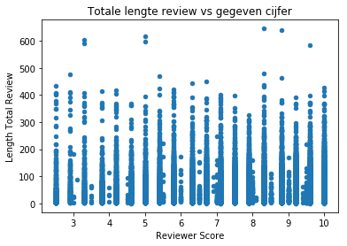

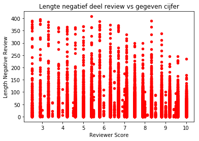

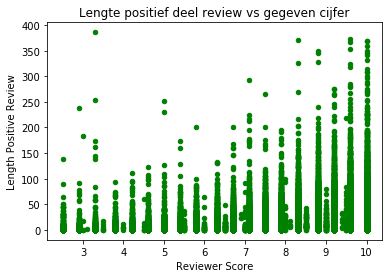

```python
# De individuele scores worden geplot tegen de lengte van de review.
amsterdam.plot(kind='scatter', x='Reviewer Score', y='Length Total Review', title="Totale lengte review vs gegeven cijfer")
amsterdam.plot(kind='scatter', x='Reviewer Score', y='Length Negative Review', c="red", title="Lengte negatief deel review vs gegeven cijfer")
amsterdam.plot(kind='scatter', x='Reviewer Score', y='Length Positive Review', c="green", title="Lengte positief deel review vs gegeven cijfer")
```

```python
print("Correlatie tussen de lengte van het positieve deel van de review en de gegeven score:", amsterdam['Length Positive Review'].corr(amsterdam['Reviewer Score']))
```

```
Correlatie tussen de lengte van het positieve deel van de review en de gegeven score: 0.209784960964
```

De vergelijking tussen de lengte van de hele review en het gegeven cijfer geeft aan dat er geen verband is tussen de twee variabelen. De mate van positiviteit (lees: de hoogte van het cijfer) is dus niet bepalend voor de lengte van de geschreven review, wat tegen onze verwachting in gaat.

De plot over lengte van het negatieve deel van de review en het gegeven cijfer geeft ook geen duidelijk verband aan. Zo valt te zien dat veel reviewers die het hotel afgerond en 10 geven, alsnog negatief commentaar hebben geleverd. Hieruit valt op te maken dat zelfs de meest tevreden gasten nog iets van commentaar hebben (dit kan natuurlijk opbouwend commentaar zijn). Dit resultaat is niet in lijn met onze verwachting.

Bij de vergelijking tussen de lengte van het positieve deel van de review en het gegeven cijfer komt een duidelijker beeld naar voren. De scatterplot laat hier een meer stijgende lijn zien, wat ook betekent dat de ontevreden gasten (lage cijfers) weinig positiefs melden over het hotel. Dit is in lijn met onze verwachting. De correlatie is echter rond de 0.2, wat wijst op een miniscuul of geen verband.

Over het algemeen is uit deze plots te zien dat het negatieve deel van de review vaak langer is dan het positieve deel van de review. Blijkbaar schrijven gasten liever meer op over hun klachten dan dat ze woorden vuil maken aan complimenten.

#### Deelvraag 2: Kunnen we het sentiment van een review voorspellen aan de hand van de gebruikte woorden? Oftewel; positiviteit of negativiteit.

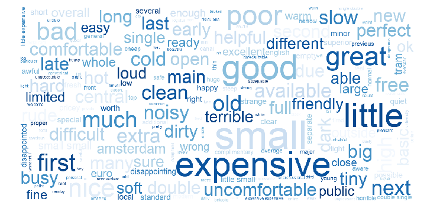

```python
adj_wordcloud(review_str_neg)
```

[figure not shown]

```python
adj_wordcloud(review_str_pos)
```

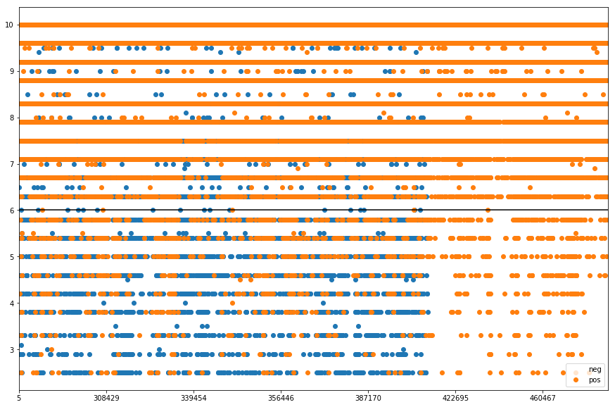

```python
# Visualisatie van het resultaat met scheidingslijn bij 6

amsterdam.groupby('Predicted')['Reviewer Score'].plot(style='o',figsize=(15,10),legend=True)
plt.plot([0,len(amsterdam)],[6,6], 'k-');
```

```python
# Het fout percentage. Hierbij nemen we 6 als de grens tussen onvoldoende en voldoende

correct = 0

for index,row in amsterdam.iterrows():
    if float(row['Reviewer Score']) < 6.0 and row['Predicted'] == 'neg':
        correct += 1
    elif float(row['Reviewer Score']) >= 6.0 and row['Predicted'] == 'pos':
        correct += 1

print(correct/len(amsterdam))
```

```
0.6369944419198098
```

Er is een duidelijk verschil te zien tussen de woorden die gebruikt worden bij positieve reviews en de woorden die gebruikt worden bij negatieve reviews. Woorden die bij de positieve wordcloud bijvoorbeeld meteen opvallen zijn: 'good, great, comfortable en excellent'. Woorden die bij de negatieve wordcloud meteen opvallen zijn bijvoorbeeld: 'small, expensive, little, poor en uncomfortable'. Het valt echter misschien ook op dat er bij de negatieve reviews veel woorden tussen staan die gezien zouden kunnen worden als positieve woorden. Dit kan komen doordat er in de oorspronkelijke tekst bijvoorbeeld 'not' voor deze woorden stond, echter wordt dat dus in de wordcloud niet meegenomen.

Er is ook een scatter plot gemaakt die laat zien hoe iedere review is geclassificeerd ten opzichte van het cijfer dat de reviewer gegeven heeft. Hierbij hanteren wij het cijfer 6 als de scheidingslijn tussen negatief en positief.

Om te kijken hoe goed de classifier presteert is er ook een goedpercentage berekend, namelijk 63,7%. Het is mooi om te zien dat bijna tweederde van de reviews correct geclassificeerd wordt wanneer we de classificaties vergelijken met het cijfer dat de reviewer gegeven heeft. Een computer kan dus wel degelijk getraind worden om het sentiment van een review te voorspellen.

#### Deelvraag 3: Zijn er verschillen in cijfers tussen de Amsterdamse stadsdelen?

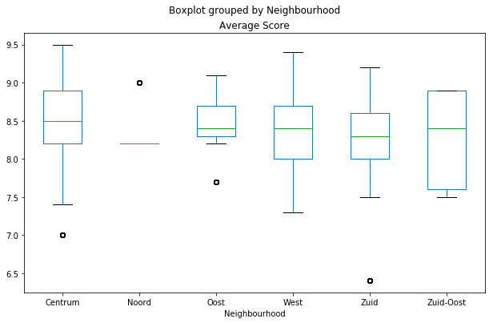

```python
# Een boxplot die de spreiding van gemiddelde scores van hotels per Amsterdamse buurt laat zien

amsterdam.boxplot(column='Average Score', by='Neighbourhood', figsize=(10,6), grid=False);
```

## CONCLUSIE

Vrijwel iedereen boekt tegenwoordig een hotel online. Op deze 'booking' websites is het ook makkelijk om een review achter te laten en verschillende al geplaatste reviews terug te lezen. Uit het literatuuronderzoek blijkt er dat er een belang bestaat voor deze hotel reviews en dat er een groeiende interesse bestaat in gebruikersdata. Daarom is er onderzocht of er conclusies kunnen worden getrokken uit de Booking.com reviews van hotels gevestigd in Amsterdam. Er is ten eerste gekeken of er een verband kan worden aangenomen tussen de lengte van de reviews en het cijfer dat wordt gegeven. Visueel lijkt er een verband te zijn bij de lengte van de positieve review en het cijfer, maar de correlatie blijkt maar 0.2 te zijn. Dat wijst op een minuscuul of geen verband. Verder is te zien dat het negatieve deel van de review vaak langer is dan het positieve deel van de review.

Ook is er gekeken of het sentiment van reviews kan worden voorspeld aan de hand van de gebruikte woorden. Dit blijkt uit het onderzoek wel het geval te zijn. Er is namelijk een duidelijk verschil te zien tussen de woorden die gebruikt worden bij positieve reviews en de woorden die gebruikt worden bij negatieve reviews. Dit met een foutpercentage van ongeveer 36.3%. Het is dus redelijk goed te voorspellen of een review in zijn geheel positief of negatief is.

Tenslotte is er onderzocht of er verschillen zijn in review cijfer tussen de Amsterdamse buurten. Dit blijkt uit het onderzoek wel het geval te zijn, maar is het lastig te interpreteren, omdat de berekende medianen redelijk gelijk zijn. Hier is namelijk vooral de berekende spreiding die verschilt.

Al met al kan het onderzoeksvraag beantwoord worden met een ‘ja’. Er kunnen namelijk conclusies worden getrokken uit reviews van hotels in Amsterdam.